# Taylor Business Group Profit Makers Report

Jexet Accounting Department

YTD 2016-May

## 1. Product Margin

This determine the amount of spread we are getting whenever there is a product sale. Benchmark is 17.75%.

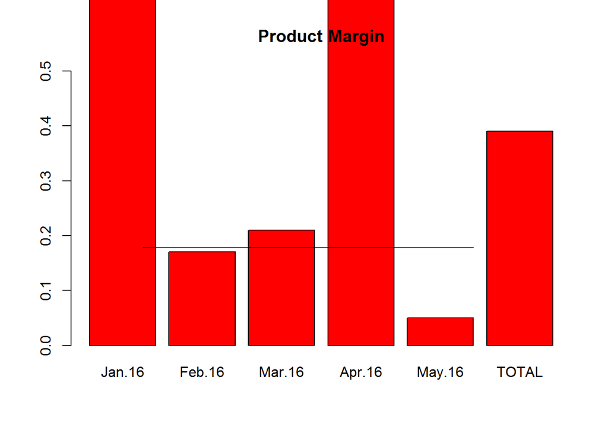

```
##                             Jan.16  Feb.16   Mar.16  Apr.16  May.16
## Total 4000 · Product Sales 2536.24 7937.47 15067.80 7185.70 1227.68
## Total 5000 · Product COGS  1373.54 6768.80 12401.58 2753.31 1164.89
## Product Margin                0.85    0.17     0.21    1.61    0.05
##                               TOTAL
## Total 4000 · Product Sales 33954.89
## Total 5000 · Product COGS  24462.12
## Product Margin                 0.39
```

## 2. Percent of Services to Total Revenue

It takes money to create money. This is how much we spend on direct labor in order to support/generate the revenue. Benchmark is 60%.

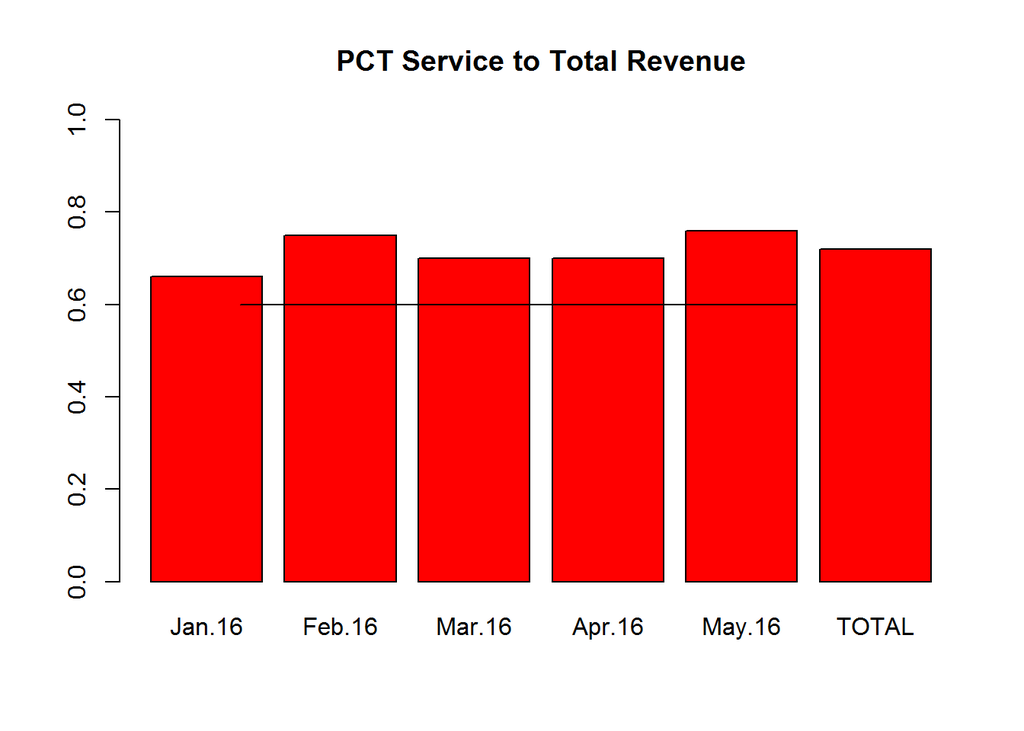

```
##                                             Jan.16   Feb.16   Mar.16
## Total Income                              86928.29 88089.71 93978.92
## Total COGS                                17672.48 27958.08 32172.12
## Total 5150 · Service Salaries and Bonuses 39954.92 38124.56 33909.05
## PCT Sevice to Total Revenue                   0.66     0.75     0.70
##                                             Apr.16   May.16     TOTAL
## Total Income                              84788.58 84700.34 438485.84
## Total COGS                                21534.54 19974.58 119311.80
## Total 5150 · Service Salaries and Bonuses 38157.92 44152.88 194299.33
## PCT Sevice to Total Revenue                   0.70     0.76      0.72
```

## 3. Percent of Annuity Revenues to Total Service Revenue

The company generates income in different ways, it can be through product sales or interest income on other vehicles (financial instrument), but for the company’s lifeblood is the service revenue. Benchmark is 60%.

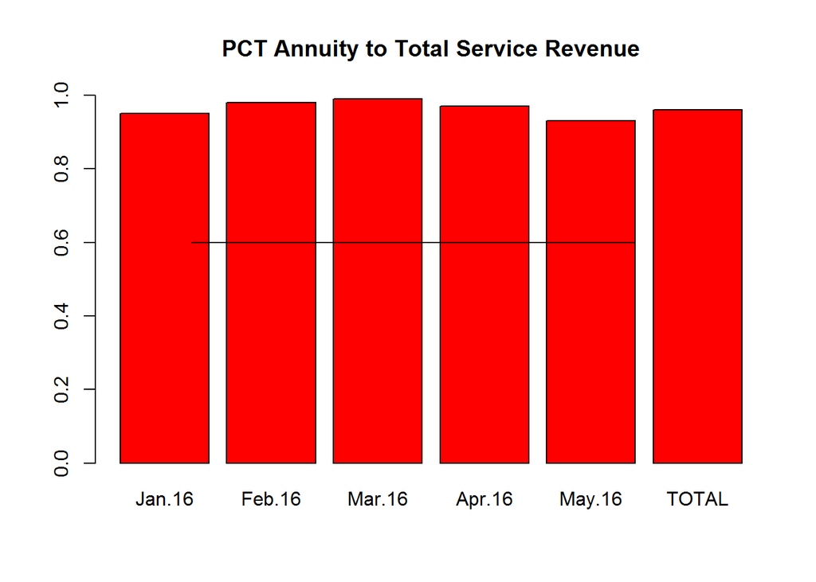

```
##                                           Jan.16   Feb.16   Mar.16
## Total 4110 · Recurring Service Revenues 80361.65 78482.31 78225.12
## Total Service Revenue                   84392.05 80152.24 78911.12
## PCT Annuity to Total Service Rev            0.95     0.98     0.99
##                                           Apr.16   May.16     TOTAL
## Total 4110 · Recurring Service Revenues 75118.88 77282.00 389469.96
## Total Service Revenue                   77602.88 83472.66 404530.95
## PCT Annuity to Total Service Rev            0.97     0.93      0.96
```

## 4. Percent of Support and Installation to Total Service Revenue

These represents the on-going add-on revenues outside the regular agreements. Benchmark is 40%.

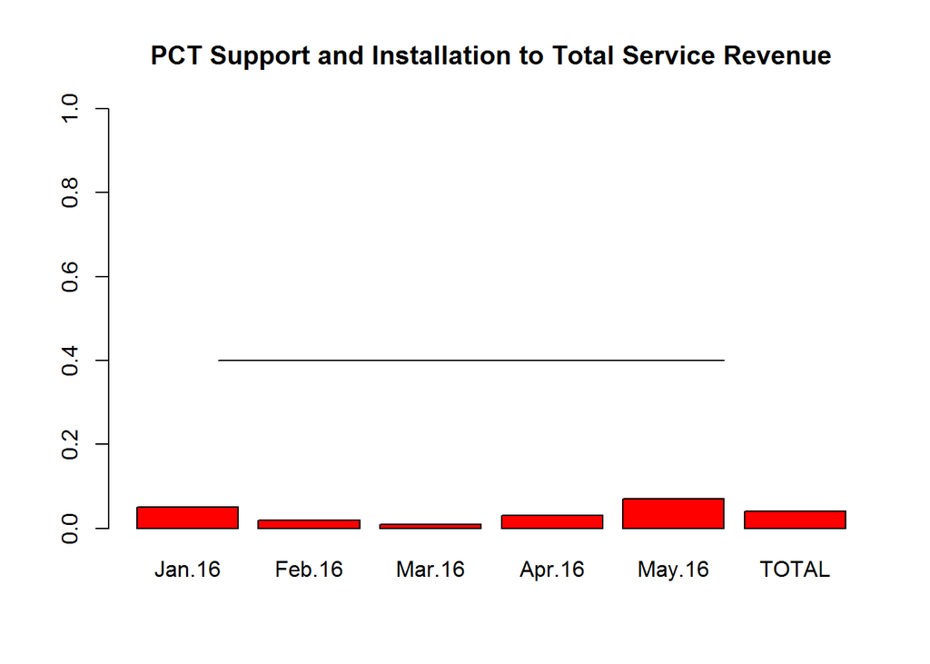

```
##                                               Jan.16   Feb.16   Mar.16
## Total 4100 · Non-Recurring Service Revenues  4030.40  1669.93   686.00
## Total Service Revenue                       84392.05 80152.24 78911.12
## PCT Supp & Instl to Total Service Rev           0.05     0.02     0.01
##                                               Apr.16   May.16     TOTAL
## Total 4100 · Non-Recurring Service Revenues  2484.00  6190.66  15060.99
## Total Service Revenue                       77602.88 83472.66 404530.95
## PCT Supp & Instl to Total Service Rev           0.03     0.07      0.04
```

## 5. Percent of Service Salaries to Service Revenue

Benchmark is 33%.

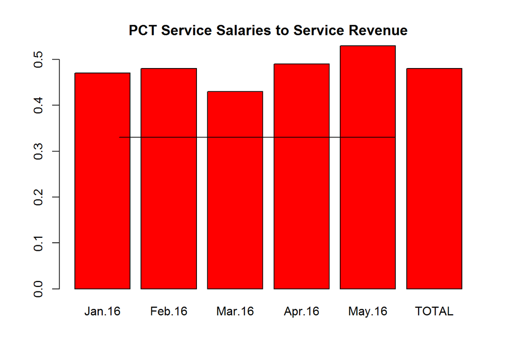

```
##                                             Jan.16   Feb.16   Mar.16
## Total 5150 · Service Salaries and Bonuses 39954.92 38124.56 33909.05
## Total Service Revenue                     84392.05 80152.24 78911.12
## PCT Service Sal to Service Rev                0.47     0.48     0.43
##                                             Apr.16   May.16     TOTAL
## Total 5150 · Service Salaries and Bonuses 38157.92 44152.88 194299.33
## Total Service Revenue                     77602.88 83472.66 404530.95
## PCT Service Sal to Service Rev                0.49     0.53      0.48
```

## 6. Percent Annuity COGS to Total Service Revenues

Total expenses directly associated in providing the service such as but not limited to labor hours, soft wares, and tools as compared to the total service revenue. Ideally, these expenses should not exceed the revenues or the benchmark set by the company which is 7%.

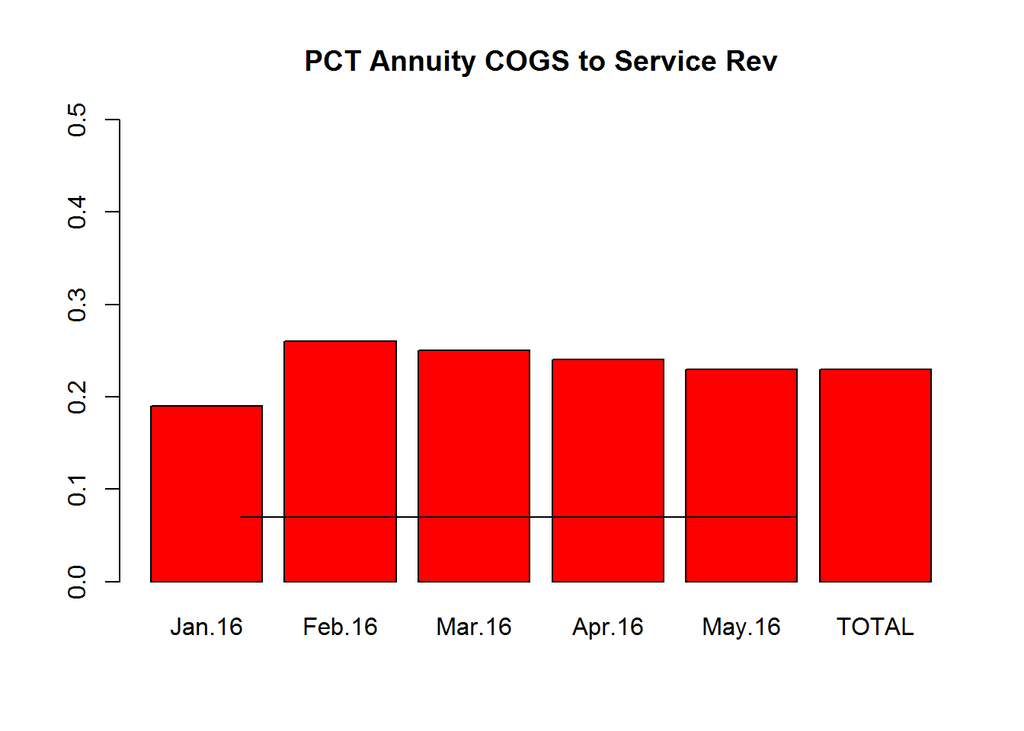

```
##                                       Jan.16   Feb.16   Mar.16   Apr.16
## Total 5100 · Recurring Service COGS 16298.94 21189.28 19770.54 18781.23
## Total Service Revenue               84392.05 80152.24 78911.12 77602.88
## PCT Annuity COGS to Service Rev         0.19     0.26     0.25     0.24
##                                       May.16     TOTAL
## Total 5100 · Recurring Service COGS 18809.69  94849.68
## Total Service Revenue               83472.66 404530.95
## PCT Annuity COGS to Service Rev         0.23      0.23
```

## 7. Percent Training Expense to Total Service Revenues

Expenses related to preparing the service team, in order to assure quality service provided to our valued customers. Benchmark is 1.5%.

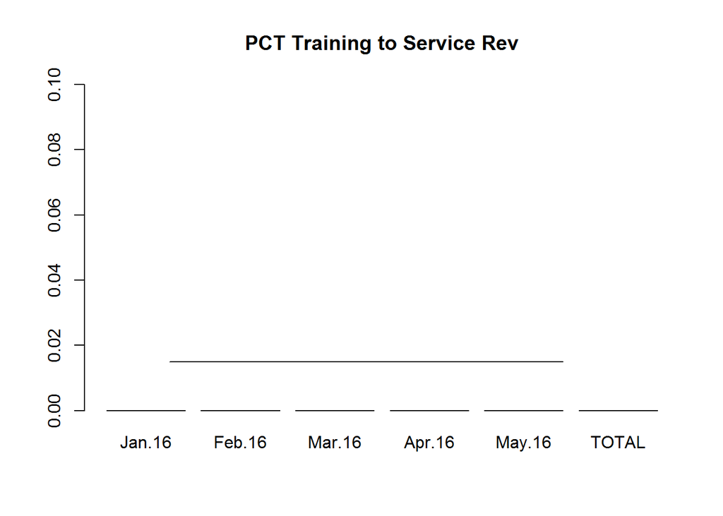

```
##                                   Jan.16   Feb.16   Mar.16   Apr.16
## 5130 · Service Training expense    50.46     0.00     0.00     0.00
## Total Service Revenue           84392.05 80152.24 78911.12 77602.88
## PCT Training to Service Rev         0.00     0.00     0.00     0.00
##                                   May.16     TOTAL
## 5130 · Service Training expense     0.00     50.46
## Total Service Revenue           83472.66 404530.95
## PCT Training to Service Rev         0.00      0.00
```

## 8. Percent Mtgs, Trvl, and Ldgng to Total Service Revenues

Benchmark is 1.5%.

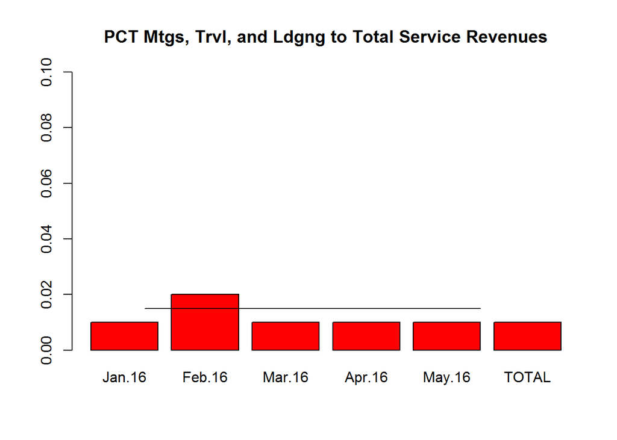

```
##                                        Jan.16   Feb.16   Mar.16   Apr.16
## Mtgs, Trvl,and Ldgng                  1003.56  1600.71   780.24  1059.74
## Total Service Revenue                84392.05 80152.24 78911.12 77602.88
## PCT Mtgs, Trvl, Ldgng to Service Rev     0.01     0.02     0.01     0.01
##                                        May.16     TOTAL
## Mtgs, Trvl,and Ldgng                  1109.78   5554.03
## Total Service Revenue                83472.66 404530.95
## PCT Mtgs, Trvl, Ldgng to Service Rev     0.01      0.01
```

## 9. Service Gross Profit Margin Ratio

This represents the residual amount after deducting total cost of good sold to the total service revenue but before any selling and administrative expenses. Benchmark is 55%.

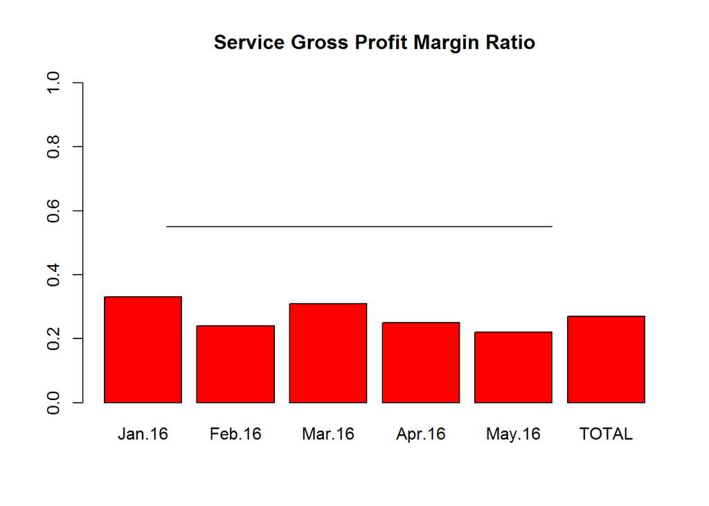

```
##                                               Jan.16   Feb.16   Mar.16
## Total 4100 · Non-Recurring Service Revenues  4030.40  1669.93   686.00
## Total 4110 · Recurring Service Revenues     80361.65 78482.31 78225.12
## Total 5100 · Recurring Service COGS         16298.94 21189.28 19770.54
## Total 5112 · Service Revenue Expenses         110.51  1238.83  1129.94
## Total 5150 · Service Salaries and Bonuses   39954.92 38124.56 33909.05
## Service Gross Profit Margin Ratio               0.33     0.24     0.31
##                                               Apr.16   May.16     TOTAL
## Total 4100 · Non-Recurring Service Revenues  2484.00  6190.66  15060.99
## Total 4110 · Recurring Service Revenues     75118.88 77282.00 389469.96
## Total 5100 · Recurring Service COGS         18781.23 18809.69  94849.68
## Total 5112 · Service Revenue Expenses        1270.94  1812.95   5563.17
## Total 5150 · Service Salaries and Bonuses   38157.92 44152.88 194299.33
## Service Gross Profit Margin Ratio               0.25     0.22      0.27
```

## 10. Sales Salaries as a Percentage of Revenue

Sales team are primary responsible for generating new customer and as well as maintaining the existing client-portfolio. Benchmark is 4.01%.

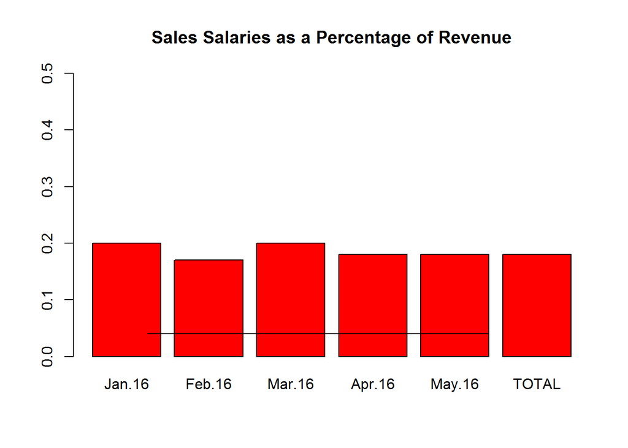

```
##                                 Jan.16   Feb.16   Mar.16   Apr.16   May.16
## 5211 · Sales Salaries         17214.41 14943.83 18541.29 15273.96 15002.06
## Total Income                  86928.29 88089.71 93978.92 84788.58 84700.34
## PCT Sales Salaries to Revenue     0.20     0.17     0.20     0.18     0.18
##                                   TOTAL
## 5211 · Sales Salaries          80975.55
## Total Income                  438485.84
## PCT Sales Salaries to Revenue      0.18
```

## 11. Sales Commissions as a Percentage of Revenue

These are commissions erned from sale for signing new deals. Benchmark is 4.49%.

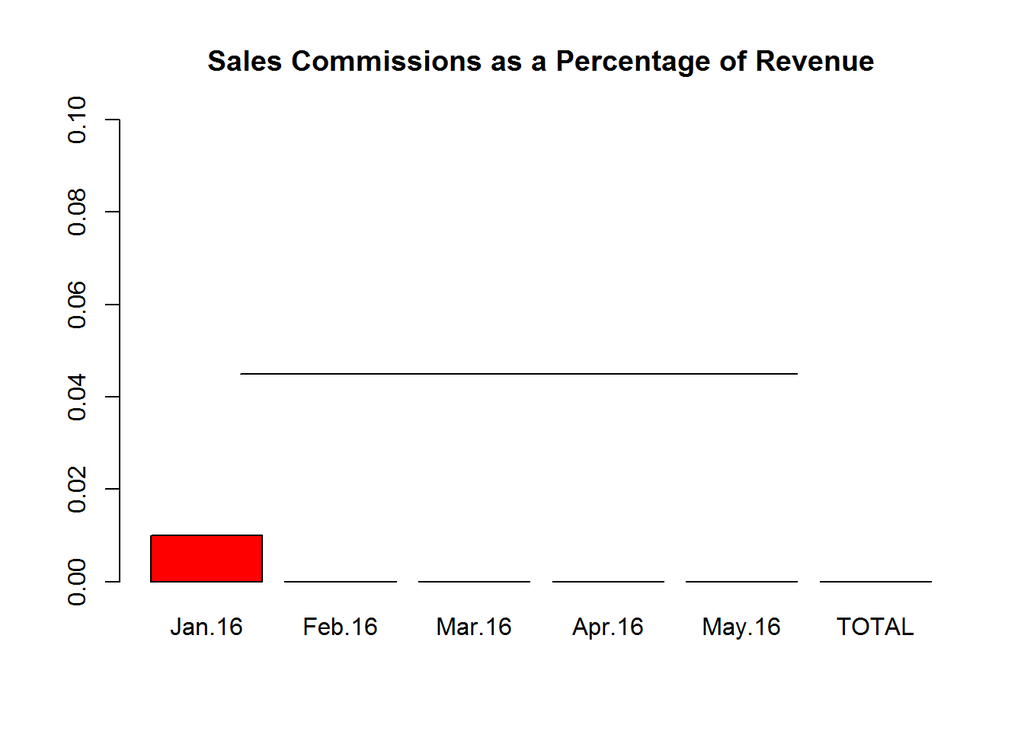

```
##                                   Jan.16   Feb.16   Mar.16   Apr.16
## 5212 · Sales Commission           453.66   417.47   338.29     0.00
## Total Income                    86928.29 88089.71 93978.92 84788.58
## PCT Sales Commission to Revenue     0.01     0.00     0.00     0.00
##                                   May.16     TOTAL
## 5212 · Sales Commission            64.84   1274.26
## Total Income                    84700.34 438485.84
## PCT Sales Commission to Revenue     0.00      0.00
```

## 12. Advertising as a Percentage of Revenue

These represents market publicity, whether we are making spending enough on advertisement to promote more sales. Benchmark is 2%.

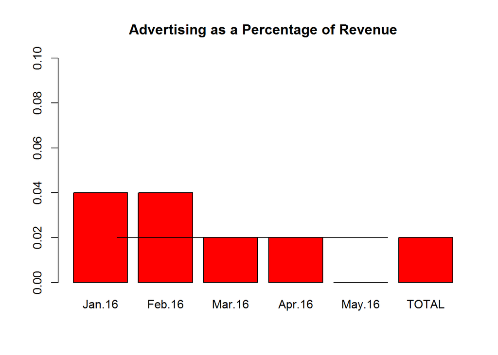

```
##                                    Jan.16   Feb.16   Mar.16   Apr.16
## Total 5240 · Marketing Compaigns  3090.79  3584.08  2021.87  1407.06
## Total Income                     86928.29 88089.71 93978.92 84788.58
## PCT Advertising to Revenue           0.04     0.04     0.02     0.02
##                                    May.16     TOTAL
## Total 5240 · Marketing Compaigns   145.36  10249.16
## Total Income                     84700.34 438485.84
## PCT Advertising to Revenue           0.00      0.02
```

## 13. Gross Profit Margin After Sales Expense

This represents the gross profit ratio amount left to support to the Marketing and administrative functions. Benchmark is 30.46%.

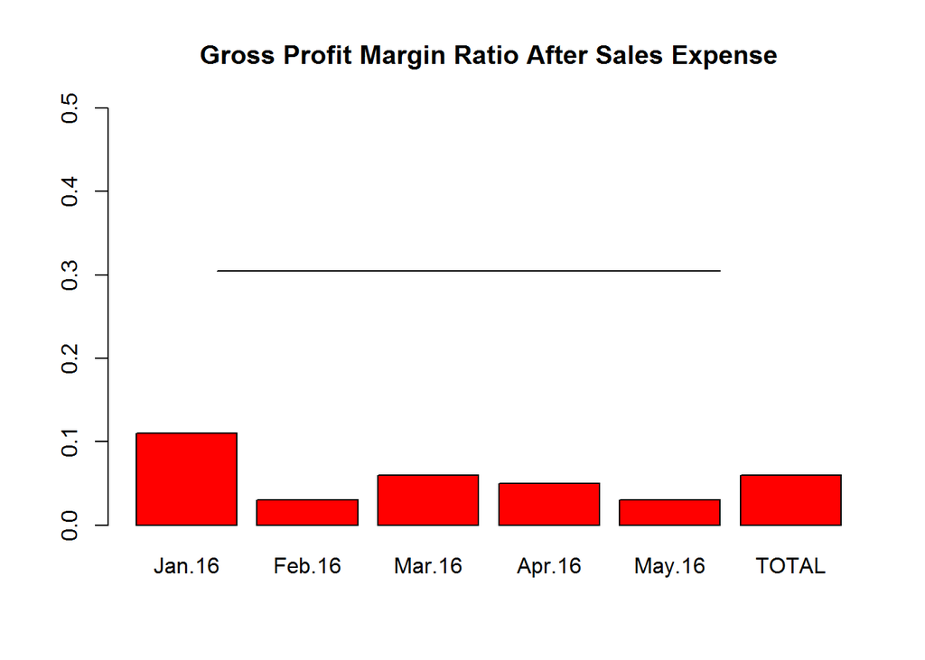

```
##                                                 Jan.16   Feb.16   Mar.16
## Total 4100 · Non-Recurring Service Revenues    4030.40  1669.93   686.00
## Total 4110 · Recurring Service Revenues       80361.65 78482.31 78225.12
## Total 5100 · Recurring Service COGS           16298.94 21189.28 19770.54
## Total 5112 · Service Revenue Expenses           110.51  1238.83  1129.94
## Total 5150 · Service Salaries and Bonuses     39954.92 38124.56 33909.05
## Total 5210 · Sales Expenses                   18552.50 16968.51 19568.25
## Gross Profit Margin Ratio After Sales Expense     0.11     0.03     0.06
##                                                 Apr.16   May.16     TOTAL
## Total 4100 · Non-Recurring Service Revenues    2484.00  6190.66  15060.99
## Total 4110 · Recurring Service Revenues       75118.88 77282.00 389469.96
## Total 5100 · Recurring Service COGS           18781.23 18809.69  94849.68
## Total 5112 · Service Revenue Expenses          1270.94  1812.95   5563.17
## Total 5150 · Service Salaries and Bonuses     38157.92 44152.88 194299.33
## Total 5210 · Sales Expenses                   15718.52 15974.56  86782.34
## Gross Profit Margin Ratio After Sales Expense     0.05     0.03      0.06
```

## 14. Admin as a Percent of Total Revenue

This represents the compnay adiministation cost standard. Benchmark is 20%.

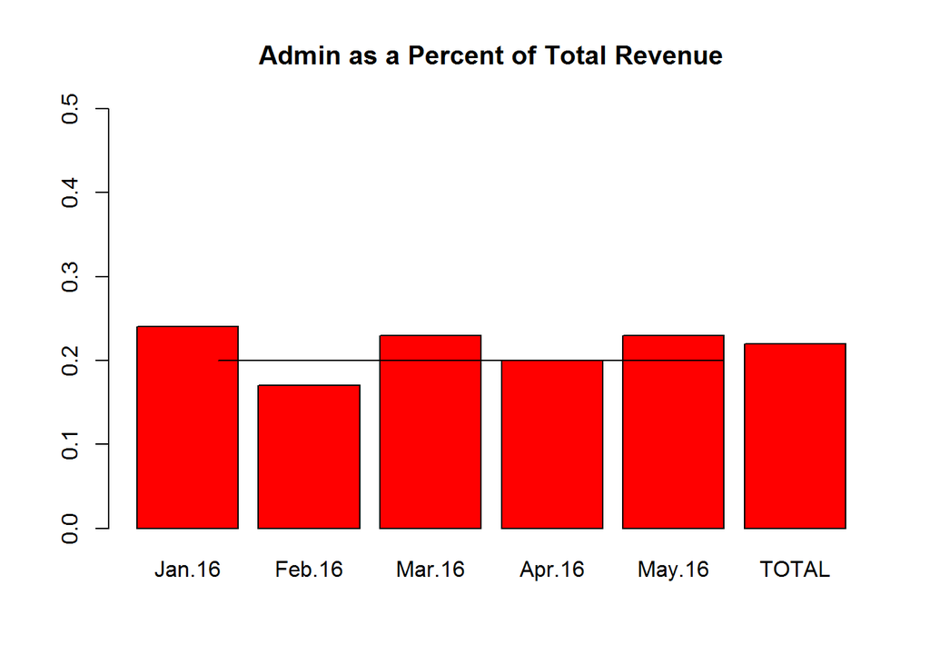

```
##                                               Jan.16   Feb.16   Mar.16
## Total 6000 · General & Administrat Expenses 21054.66 15256.99 21833.13
## Total Income                                86928.29 88089.71 93978.92
## PCT Admin to Revenue                            0.24     0.17     0.23
##                                               Apr.16   May.16     TOTAL
## Total 6000 · General & Administrat Expenses 16869.29 19275.93  94290.00
## Total Income                                84788.58 84700.34 438485.84
## PCT Admin to Revenue                            0.20     0.23      0.22
```

## 15. Net Operating Profit Margin

This represents the residual amount after deducting all the expenses for the period to the service revenues that are all part of normal operation of the business. This does not included any income or expenses associated with investment and long term capital financing. Benchmark is 10.46%.

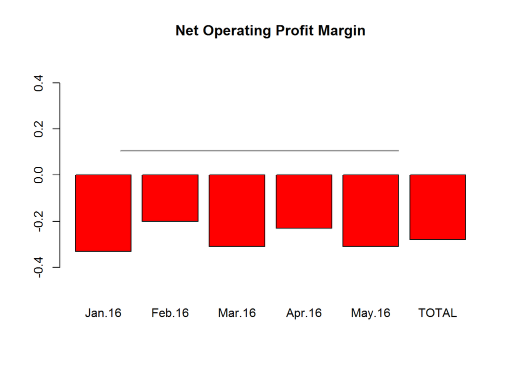

```
##                                      Jan.16    Feb.16    Mar.16    Apr.16
## Net Ordinary Income               -28989.21 -18019.30 -29464.95 -19743.82
## Total Income                       86928.29  88089.71  93978.92  84788.58
## Net Operating Profit Margin Ratio     -0.33     -0.20     -0.31     -0.23
##                                      May.16      TOTAL
## Net Ordinary Income               -26504.91 -122722.19
## Total Income                       84700.34  438485.84
## Net Operating Profit Margin Ratio     -0.31      -0.28
```

## 16. Monthly Service Revenue per Service Person

This is a per individual allocation of monthly service revenue. Just divide the monthly service revenue by the total number of service person. Benchmark is $15,600.

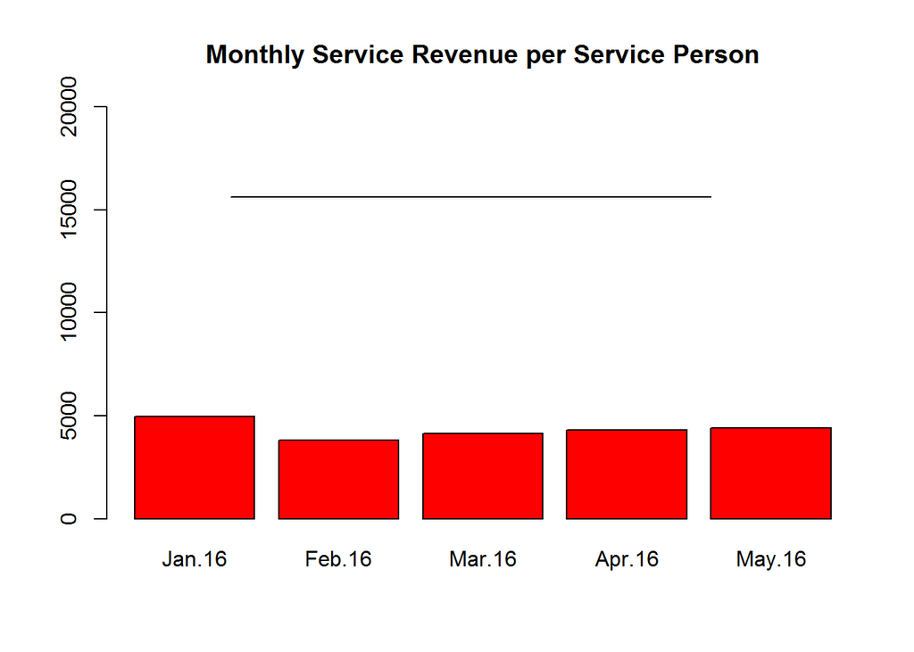

```
##                                    Jan.16 Feb.16 Mar.16 Apr.16 May.16
## Total Service Rev                   84392  80152  78911  77603  83473
## # of Service Staff                     17     21     19     18     19
## Service Revenue per Service Person   4964   3817   4153   4311   4393
```

## 17. Monthly Service Gross Profit per Service Person

Monthly contribution margin divided by the number of service person. Benchmark is $8,580.

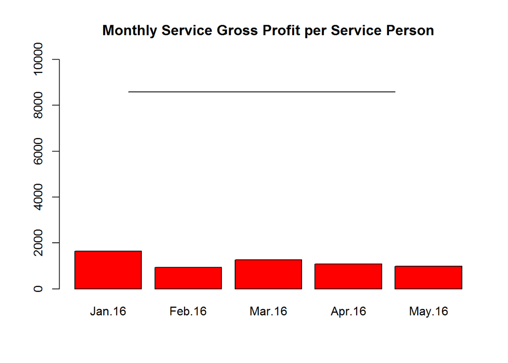

```
##                                         Jan.16 Feb.16 Mar.16 Apr.16 May.16
## Service Gross Profit                     28028  19600  24102  19393  18697
## # of Service Staff                          17     21     19     18     19
## Service Gross Profit per Service Person   1649    933   1269   1077    984
```

## 18. Monthly Revenue per Employee

Monthly revenues divided by the total number of employed individual. Benchmark is $20,000.

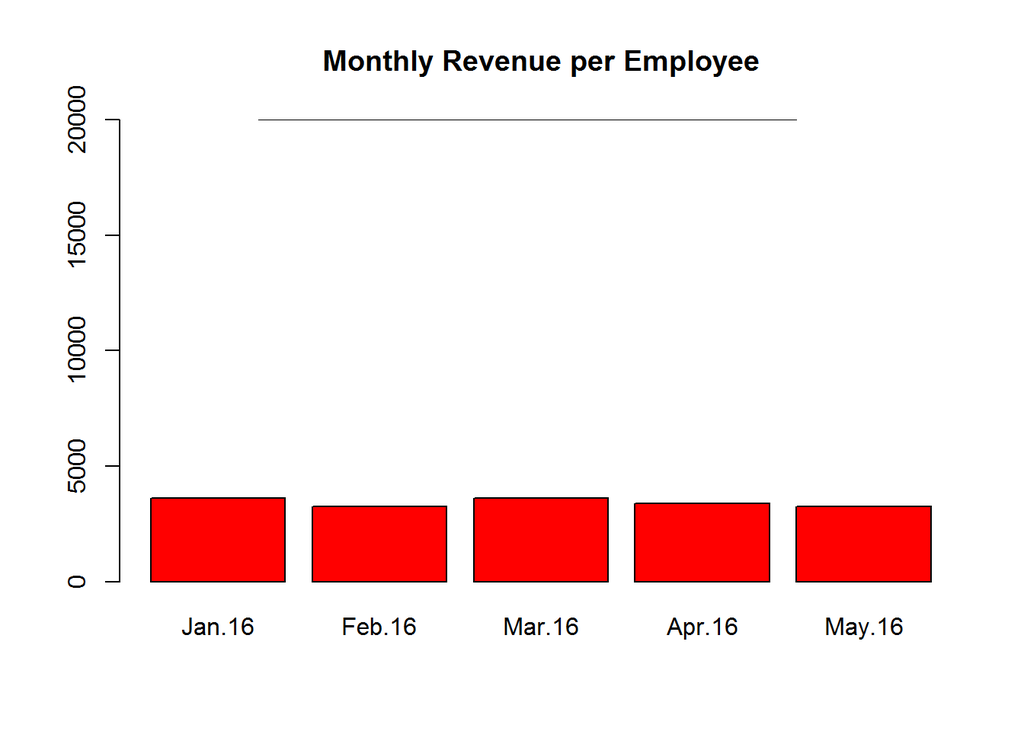

```
##                      Jan.16 Feb.16 Mar.16 Apr.16 May.16
## Total Income          86928  88090  93979  84789  84700
## # of Employee            24     27     26     25     26
## Revenue per Employee   3622   3263   3615   3392   3258
```

## 19. Net Operating Profit per Employee

Net Income from normal operation of business over the total number of employees. Benchmark is $2,000.

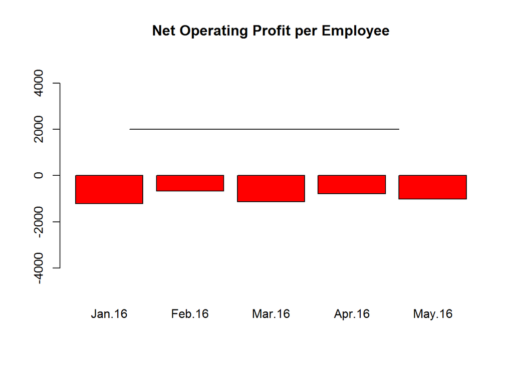

```
##                                   Jan.16 Feb.16 Mar.16 Apr.16 May.16
## Net Ordinary Income               -28989 -18019 -29465 -19744 -26505
## # of Employee                         24     27     26     25     26
## Net Operating Profit per Employee  -1208   -667  -1133   -790  -1019
```